# Genomic Variants Exercises ~ Session 1

Rockefeller University, Bioinformatics Resource Centre

https://rockefelleruniversity.github.io/RU_GenomicVariants/

## Genomic Variant manipulation

In this exercise, we will practice how to manipulate VCF files. Please find this VCF file “data/SAMN01882168_filt.vcf.gz” and use it to answer the following questions.

1. Read in the VCF file and make a VRange object
2. Please extract the genotype field and explain the abbreviations

```
## DataFrame with 10 rows and 3 columns
##             Number        Type            Description
##        <character> <character>            <character>
## GT               1      String               Genotype
## AD               R     Integer Allelic depths for t..
## DP               1     Integer Approximate read dep..
## GQ               1     Integer       Genotype Quality
## MIN_DP           1     Integer Minimum DP observed ..
## PGT              1      String Physical phasing hap..
## PID              1      String Physical phasing ID ..
## PL               G     Integer Normalized, Phred-sc..
## RGQ              1     Integer Unconditional refere..
## SB               4     Integer Per-sample component..
```

3. Please calculate the incidence of mutation occurence in each chromosome.
- Incidence: variant per kilobase
- Chromosome length in reference genome: *seqlengths()*
- Variants per chromosome: *table(seqnames())*

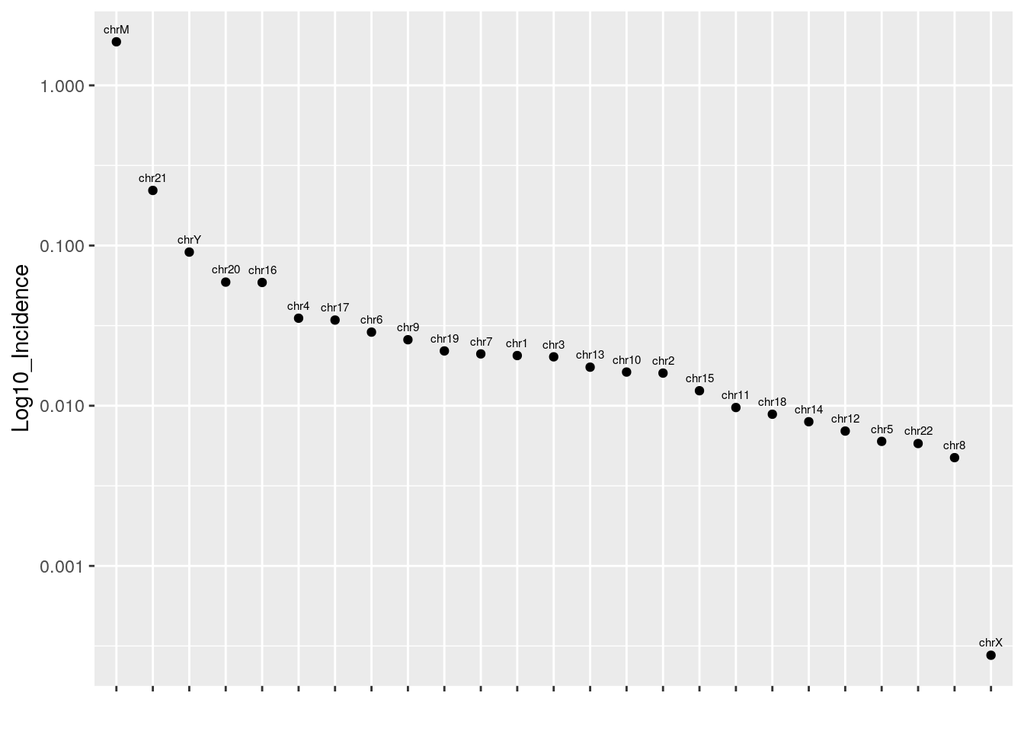

4. Subset to just the variants on Chr21.
5. Extract GT information from VCF subset and make a barchart to describe the variant number in each genotype.

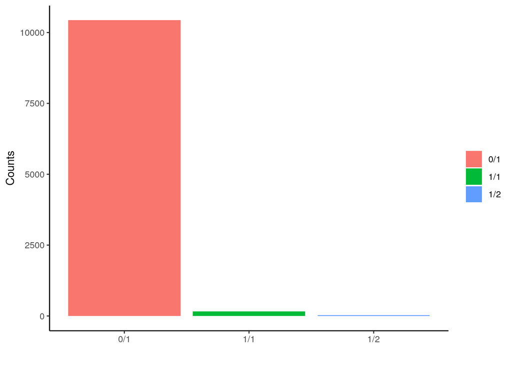

6. Extract DP information from VCFf subset and make a histogram.
- use ggplot to make histogram
- scale x axis as log10: *scale_x_log10()*

```
##    Min. 1st Qu.  Median    Mean 3rd Qu.    Max.
##    3.00   13.00   19.00   25.05   30.00  629.00
```

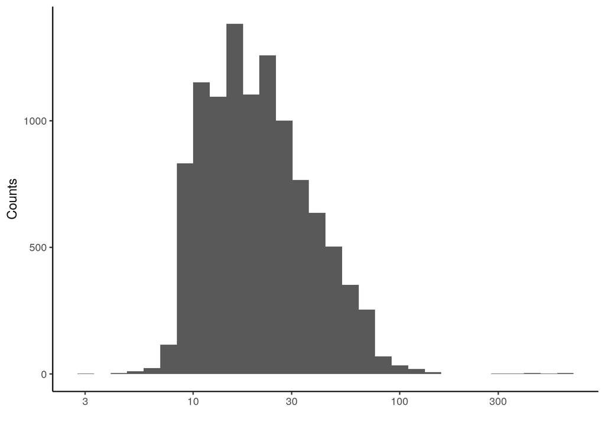

7. Extract GQ information from VCF subset and make histogram
- use ggplot to make histogram
- scale x axis as log10

```
##    Min. 1st Qu.  Median    Mean 3rd Qu.    Max.
##    0.00   99.00   99.00   91.32   99.00   99.00
```

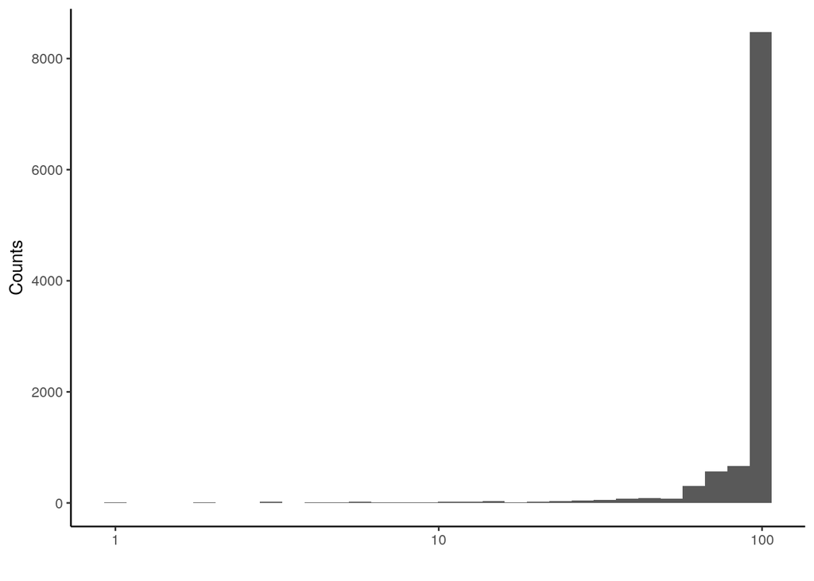

8. Please make a data.frame including the following information demonstrated below.

```
##              variant   chr   start     end refBase altBase refCount altCount
## 1 chr21:9412358_TA/T chr21 9412358 9412359      TA       T        6        4
## 2  chr21:9413584_G/A chr21 9413584 9413584       G       A        3        8
##   genoType gtQuality
## 1      0/1        81
## 2      0/1        62
```

9. Please differentiate variants by types (SNP/INS/DEL/Others) and count variants by each type
- SNP: single nucleotide substitution, length(refBase) = length(altBase) = 1
- INS: insertion, length(refBase) < length(altBase)
- DEL: deletion, length(refBase) > length(altBase)
- Others: might be complicated substitutions, eg. insdel, length(refBase) = length(altBase) <> 1

```
##
##  DEL  INS  SNP
##  612  482 9536
```

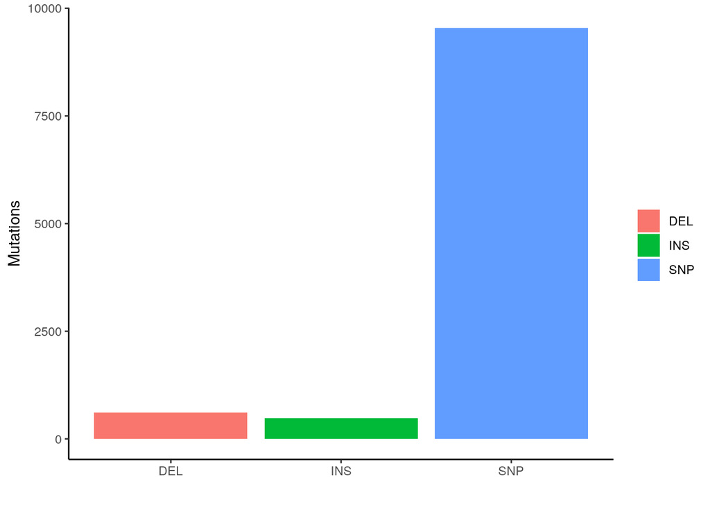

10. Evaluate nucleotide substitutions
- only focus on SNPs
- Nucleotide substitutions:
  - Transition: A>G, G>A, C>T, T>C
  - Transversion: A>T, A>C, G>T, G>C, C>A, C>G, T>A, T>G

```
##              variant   chr   start     end refBase altBase refCount altCount
## 1 chr21:9412358_TA/T chr21 9412358 9412359      TA       T        6        4
## 2  chr21:9413584_G/A chr21 9413584 9413584       G       A        3        8
##   genoType gtQuality mutType nuSub TiTv
## 1      0/1        81     DEL  TA>T <NA>
## 2      0/1        62     SNP   G>A   Ti
```

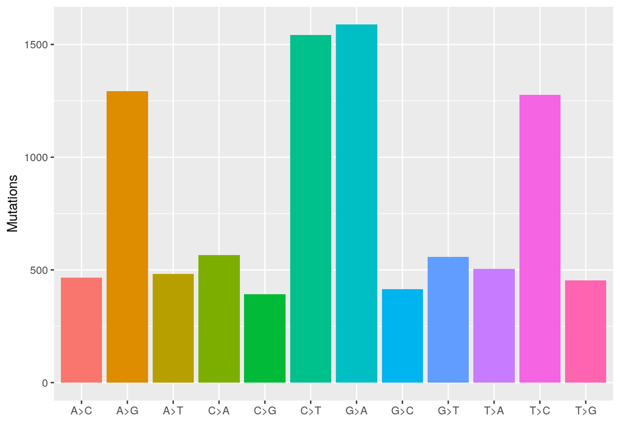

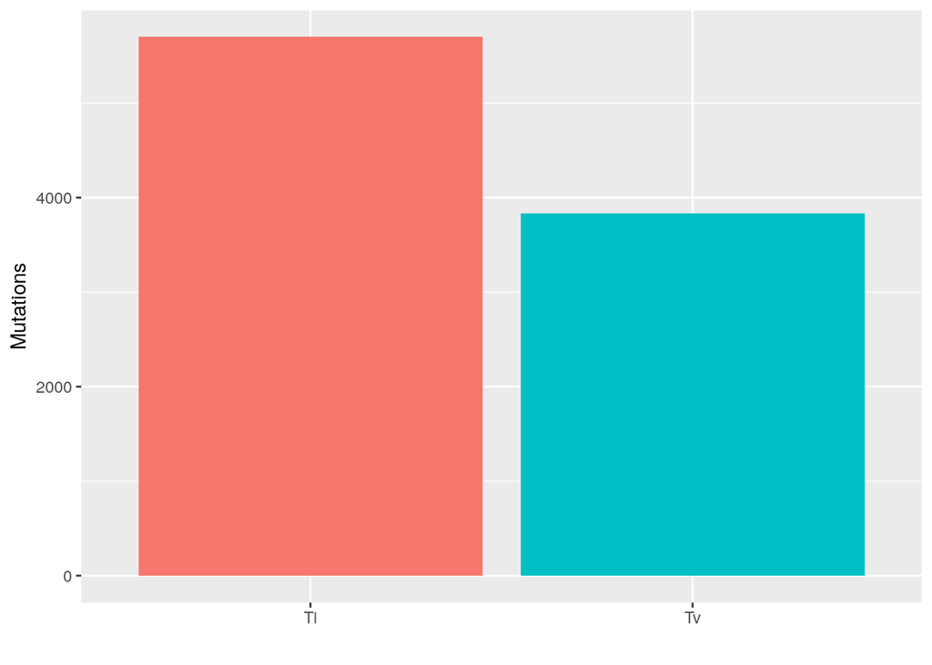